# Factors Affecting Loan Payments

## by Sylvia Ngari

## Investigation Overview

In this investigation, I wanted to look at some factors that may affect loan payment completion. The main variables considered are loan terms, previous delinquency status, income, and loan amounts.

## Dataset Overview

The dataset initially contained 81 attributes of 113,937 loans. This dataset was trimmed down to 10 columns and 50066 rows by considering only chargedoff and completed loans. Of the 10 columns, two were added that grouped loans based on loan amouns and whether the client had previous delinquencies.

## Distribution of Loans by Term

3-year loans make up the bulk of Prosper loans

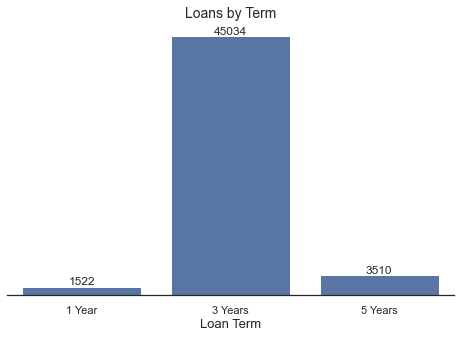

## Loans by Loan Status

Most of the Prosper loans are fully paid off.

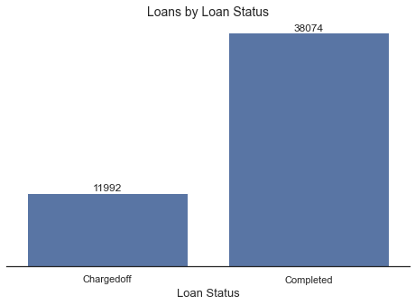

## Loan Status by Term

Across the three terms, Completed loans far exceed chargedoff loans.  
1-Year loans have the highest loan completion rate at 95.3%.  
The completion rate decreases as loan terms increase.

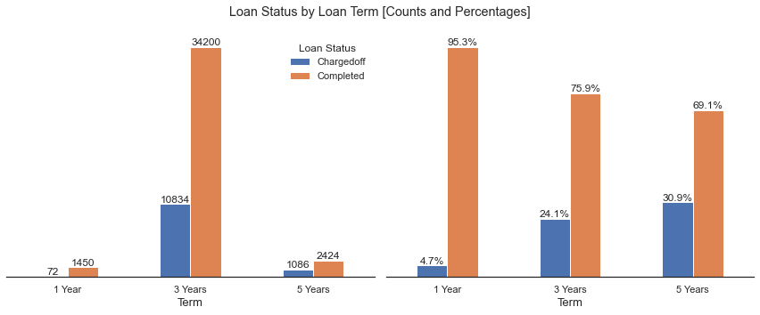

## Loan Status by Income

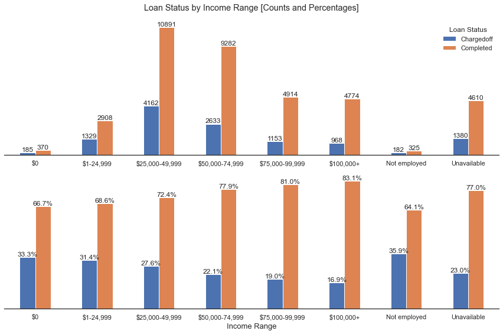

## Loan Status by Loan Amount

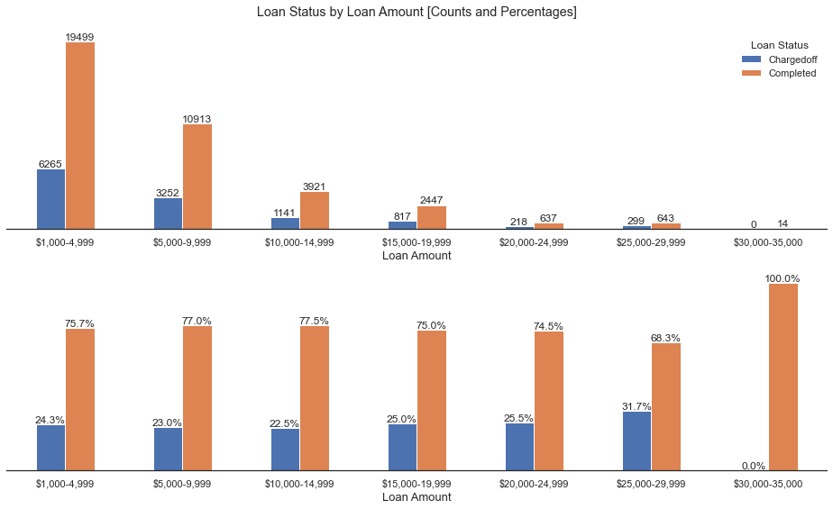

## Loan Status by Delinquency History

Most of the Prosper clients had no prior delinquencies. However, 21% of those without prior delinquencies didn't pay off their Prosper loans.  
Of the ones with past delinquencies, 63% paid off their Prosper loans

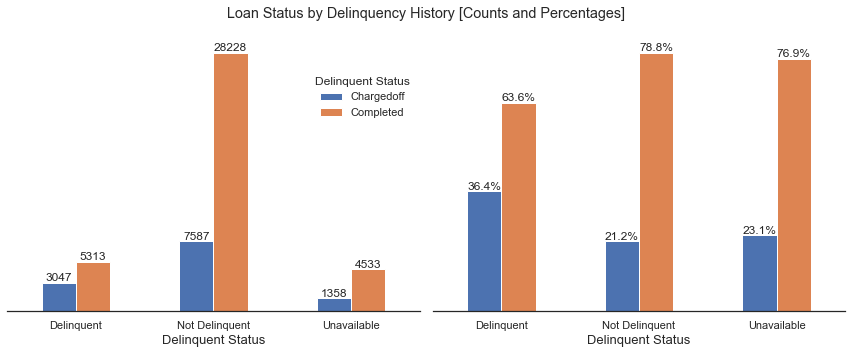